# Projekt ZED

Mateusz Borowiak 117279

04 grudzień, 2017

# 1 Wstęp

Na podstawie danych pochodzących z trzech sąsiadujących elektrowni słonecznych we Włoszech, należało określić jakie czynniki najlepiej pozwalają przewidzieć energię (atrybut kwh) wytwarzaną przez panele fotowoltaiczne. Na podstawie analizy zbioru danych, można stwierdzić, że dane były mierzone od 2 stycznia 2012r. do 31 grudnia 2013r. Pochodziły z 17 czujników, znajdujących się w różnych miejscach (różne współrzędne geograficznie). Pomiary były gromadzone każdego dnia od godz 2:00 do 20:00. Atrybutami, które najlepiej potrafią przewidzieć energię wytwarzaną przez panele fotowoltaiczne są te związane z natężeniem promieniowania słonecznego (irradiamento i irr_pvgis_mod ).

# 2 Codebook

Odszyfrowane zmienne:

- kwh - wytwarzana energia
- temperatura_ambiente - temperatura
- irradiamento - natężenie promieniowania słonecznego
- pressure - ciśnienie atmosferyczne
- windspeed - prędkość wiatru
- humidity - wilgotność powietrza
- dewpoint - temperatura punktu rosy
- windbearing - kierunek wiatru
- cloudcover - zachmurzenie
- altitude - wysokość bezwględna
- azimuth - azymut
- lat - szerokość geograficzna
- lon - długość geograficzna
- id - identyfikator pomiaru
- idsito - identyfikator czujnika
- idmodel - identyfikator modelu czujnika
- idbrand - identyfikator marki czujnika
- ora - rok pomiaru
- day - dzień pomiaru
- ora - godzina pomiaru
- data - data wraz z godziną pomiaru

# 3 Wykorzystane biblioteki

```r
library(dplyr)
library(ggplot2)
library(purrr)
library(tidyr)
library(reshape2)
library(corrr)
library(ggcorrplot)
library(gganimate)
library(caret)
library(hydroGOF)
```

# 4 Powtarzalność wyników przy każdym uruchomieniu raportu

```r
set.seed(0)
```

# 5 Wczytanie danych z pliku

```r
ds <- read.csv("elektrownie.csv")
```

# 6 Rozmiar zbioru danych

```r
dim(ds)
```

```
## [1] 235790     51
```

Zbiór danych zawiera 235790 obserwacji o 51 atrybutach.

# 7 Podsumowanie podstawowych statystyk zbioru danych

```r
summary(ds)
```

```
##        id             idsito          idmodel          idbrand
##  Min.   :     1   Min.   :0.0000   Min.   :0.0000   Min.   :0.0000
##  1st Qu.: 99646   1st Qu.:0.1000   1st Qu.:0.1670   1st Qu.:0.0830
##  Median :158594   Median :0.2250   Median :0.2080   Median :0.1670
##  Mean   :152703   Mean   :0.2147   Mean   :0.2426   Mean   :0.1519
##  3rd Qu.:217541   3rd Qu.:0.3250   3rd Qu.:0.2920   3rd Qu.:0.1670
##  Max.   :276488   Max.   :0.4250   Max.   :0.7500   Max.   :0.4170
##
##       lat              lon          ageinmonths          anno
##  Min.   :0.4150   Min.   :0.1540   Min.   :0.0000   Min.   :2012
##  1st Qu.:0.4370   1st Qu.:0.6200   1st Qu.:0.0000   1st Qu.:2012
##  Median :0.4370   Median :0.6240   Median :0.1250   Median :2012
##  Mean   :0.4495   Mean   :0.5711   Mean   :0.3145   Mean   :2012
##  3rd Qu.:0.4390   3rd Qu.:0.6300   3rd Qu.:0.7190   3rd Qu.:2013
##  Max.   :0.5530   Max.   :0.6910   Max.   :1.0000   Max.   :2013
##
##       day              ora                    data
##  Min.   :0.0000   Min.   :0.000   1/1/2013 10:00:    17
##  1st Qu.:0.2520   1st Qu.:0.222   1/1/2013 11:00:    17
##  Median :0.4770   Median :0.500   1/1/2013 12:00:    17
##  Mean   :0.4812   Mean   :0.500   1/1/2013 13:00:    17
##  3rd Qu.:0.7100   3rd Qu.:0.778   1/1/2013 14:00:    17
##  Max.   :1.0000   Max.   :1.000   1/1/2013 15:00:    17
##                                   (Other)       :235688
##  temperatura_ambiente  irradiamento       pressure        windspeed
##  Min.   :0.0450       Min.   :0.0000   Min.   :0.0000   Min.   :0.00000
##  1st Qu.:0.2120       1st Qu.:0.0000   1st Qu.:0.7480   1st Qu.:0.04200
##  Median :0.3480       Median :0.0350   Median :0.7530   Median :0.06600
##  Mean   :0.3734       Mean   :0.1091   Mean   :0.6504   Mean   :0.07622
##  3rd Qu.:0.5300       3rd Qu.:0.2040   3rd Qu.:0.7550   3rd Qu.:0.10200
##  Max.   :0.8180       Max.   :0.7100   Max.   :0.7690   Max.   :0.69600
##
##     humidity           icon           dewpoint       windbearing
##  Min.   :0.1600   Min.   :0.0000   Min.   :0.1390   Min.   :0.0000
##  1st Qu.:0.5400   1st Qu.:0.0830   1st Qu.:0.5350   1st Qu.:0.3000
##  Median :0.7000   Median :0.6670   Median :0.6190   Median :0.4780
##  Mean   :0.6844   Mean   :0.4623   Mean   :0.6055   Mean   :0.4512
##  3rd Qu.:0.8400   3rd Qu.:0.6670   3rd Qu.:0.6830   3rd Qu.:0.6600
##  Max.   :1.0000   Max.   :0.7500   Max.   :0.8650   Max.   :0.7690
##
```

[output cut: 49 more lines]

```
##  Min.   :0.0000   Min.   :0.0000   Min.   :0.1370   Min.   :0.0000
##  1st Qu.:0.2570   1st Qu.:0.7480   1st Qu.:0.6140   1st Qu.:0.4320
##  Median :0.3270   Median :0.7600   Median :0.6140   Median :0.4730
##  Mean   :0.3236   Mean   :0.7568   Mean   :0.6501   Mean   :0.4893
##  3rd Qu.:0.3270   3rd Qu.:0.8840   3rd Qu.:0.7380   3rd Qu.:0.5300
##  Max.   :1.0000   Max.   :1.0000   Max.   :1.0000   Max.   :1.0000
##
##      pcnm15       irr_pvgis_mod    irri_pvgis_mod         kwh
##  Min.   :0.0000   Min.   :0.0000   Min.   :-0.0250   Min.   :0.0000
##  1st Qu.:0.6120   1st Qu.:0.0000   1st Qu.: 0.1580   1st Qu.:0.0000
##  Median :0.6140   Median :0.0560   Median : 0.1940   Median :0.0490
##  Mean   :0.5709   Mean   :0.1767   Mean   : 0.1967   Mean   :0.1688
##  3rd Qu.:0.6150   3rd Qu.:0.3250   3rd Qu.: 0.2130   3rd Qu.:0.3320
##  Max.   :1.0000   Max.   :1.0000   Max.   : 1.0060   Max.   :1.0000
##
```

# 8 Brakujące wartości

```r
sum(is.na(ds))
```

```
## [1] 0
```

Brak jest wartości nieokreślonych NA. Jednakże występują zerowe wartości kwh, gdy takie nie powinny być, czyli gdy natężenie promieniowania słonecznego jest większe od 0. Dlatego gdy kwh=0, a atrybuty związane z natężeniem promieniowania słonecznego mają większą wartość niż progowe 0.005 to za kwh podstawiamy średnią miesięczną w tej godzinie w danym roku tego czujnika.

```r
dsProperKwh<-ds %>%
  mutate(monthYear=format(strptime(data, "%m/%d/%Y %H:%M"),"%Y-%m"),hour=format(strptime(data, "%m/%d/%Y %H:%M"),"%H:%M")) %>%
  group_by(idsito,monthYear,hour) %>%
  mutate(kwh = ifelse(kwh==0.0 & irradiamento>0.005 & irr_pvgis_mod>0.005, mean(kwh), kwh))

dsCleaned<-ds %>% mutate(kwh=dsProperKwh$kwh)
```

# 9 Wykres przedstawiający rozkład wartości atrybutów

```r
dsCleaned %>%
  keep(is.numeric) %>%
  gather() %>%
  ggplot(aes(x=value)) +
  facet_wrap(~ key, scales = "free", ncol=6) +
  geom_density(size=1.3)+
  theme(strip.text.x = element_text(size = 30),axis.title=element_text(size=20,face="bold"),axis.text=element_text(size=20))
```

[figure not shown]

Analizując nazwy atrybutów można stwierdzić, że występuje 11 par atrybutów o zbliżonych nazwach:

- temperatura_ambiente - tempi
- irradiamento - irri
- irr_pvgis_mod - irri_pvgis_mod
- pressure - pressurei
- windspeed - windspeedi
- humidity - humidityi
- dewpoint - dewpointi
- windbearing - windbearingi
- cloudcover - cloudcoveri
- altitude - altitudei
- azimuth - azimuthi

Z rozkładów wartości atrybutów widać, że drugie kolumny w parach (kończące się na i) mają o wiele bardziej skoncentrowane rozkłady wartości od ich odpowiedników. Ponadto z zestawienia korelacji atrybutów względem wytwarzanej energii (kolumna kwh)

```r
dsCleaned %>%
  keep(is.numeric) %>%
  correlate() %>%
  focus(kwh) %>%
  arrange(desc(abs(kwh))) %>%
  print(n = 49)
```

```
## # A tibble: 49 x 2
##                 rowname           kwh
##                   <chr>         <dbl>
##  1         irradiamento  0.8599952908
##  2        irr_pvgis_mod  0.8423082084
##  3             humidity -0.5319674650
##  4             azimuthi -0.4887496003
##  5                 irri  0.4023656593
##  6             altitude  0.4000185753
##  7                tempi  0.2463281046
##  8                 dist -0.2275713733
##  9       irri_pvgis_mod  0.2270133496
## 10 temperatura_ambiente  0.2054987128
## 11              azimuth -0.1766720107
## 12                   id  0.1559683316
```

[output cut: 37 more lines]

wynika, że we wszystkich parach oprócz temperatura_ambiente - tempi i azimuth - azimuthi wartośc bezwględnej korelacji względem kwh jest większa dla pierwszej kolumny z pary. Dlatego usuniemy z naszego zbioru danych atrybuty: tempi, irri, irri_pvgis_mod, pressurei, windspeedi, humidityi, dewpointi, windbearingi, cloudcoveri, altitudei i azimuthi.

```r
ds40var <- select(dsCleaned, -(tempi:cloudcoveri), -(altitudei:azimuthi), -irri_pvgis_mod)
dim(ds40var)
```

```
## [1] 235790     40
```

Otrzymujemy zbiór 40 atrybutowy.

# 10 Macierz korelacji

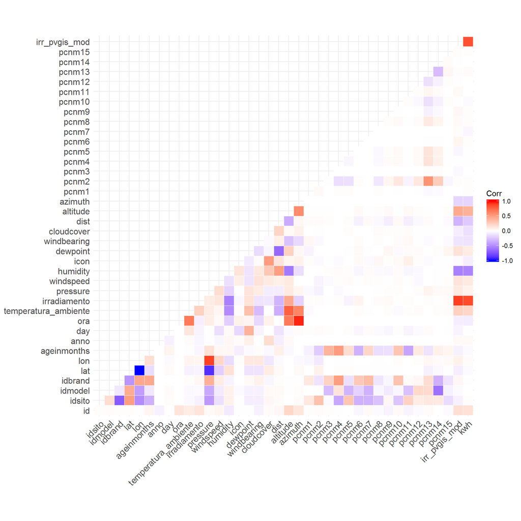

```r
corList<-ds40var %>%
  keep(is.numeric) %>%
  cor() %>%
  round(2) %>%
  melt

corr<-ds40var %>%
  keep(is.numeric) %>%
  cor() %>%
  round(2)

ggcorrplot(corr, type = "lower",
           outline.col = "white")
```

# 11 Animacja prezentującą zmianę wytwarzanej energii w czasie i w zalezności od pozycji czujnika

```r
ds40varGroupedByMonth<-ds40var %>%
  mutate(monthYear=format(strptime(data, "%m/%d/%Y %H:%M"),"%Y-%m")) %>%
  group_by(monthYear,idsito) %>% summarize(sumKwh=sum(kwh))

p<-ggplot(ds40varGroupedByMonth,aes(x=monthYear,y=sumKwh,frame=idsito,group=1))+geom_line()+ theme(axis.text.x = element_text(angle = 45, hjust = 1))
gganimate(p)
```

[video not shown]

Uwagę zwraca niemal zerowe wytworzenie energii w styczniu 2013 przez czujniki o identyfikatorach 0.025, 0.05, 0.075, 0.425 oraz w sierpniu 2013 przez czujnik o identyfikatorze 0.4.

# 12 Regresor przewidujący wytwarzaną energię

```r
regressionData <- ds40var %>% dplyr::select(irradiamento, irr_pvgis_mod, humidity, altitude, dist, temperatura_ambiente, azimuth, cloudcover,kwh)

set.seed(0)
inTraining <-
  createDataPartition(
    y = regressionData$kwh,
    p = .70,
    list = FALSE)

trainingSet <- regressionData[ inTraining,]
testingSet  <- regressionData[-inTraining,]


fitRlm <- train(kwh ~ .,
                  data = trainingSet,
                  method = "rlm",
                  trControl = trainControl(method="cv", number=5, preProcOptions = c("center", "scale")))


predictedRlm<-predict(fitRlm,testingSet)

rmseTrain<-min(fitRlm$results$RMSE)
rmseTest<-rmse(predictedRlm,testingSet$kwh)
```

# 13 Analiza ważności atrybutów modelu regresji

```r
varImp(fitRlm)
```

```
## loess r-squared variable importance
##
##                      Overall
## irradiamento         100.000
## irr_pvgis_mod         95.764
## humidity              37.001
## altitude              19.858
## dist                   4.859
## temperatura_ambiente   3.520
## azimuth                2.010
## cloudcover             0.000
```

Najlepiej przewidzieć energię wytwarzaną przez panel pozwala natężenia promieniowania słonecznego (irradiamento). Atrybut ten uzyskał 100% w badaniu ważności atrybutów. Na kolejnych miejscach znalazła się inna zmienna dotycząca promieniowania słonecznego (irr_pvgis_mod) i wilgotność powietrza (humidity).